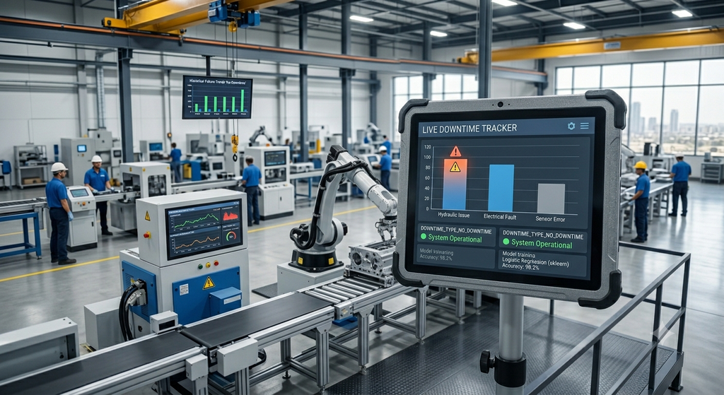

# 📊 Manufacturing Downtime Analysis

### 🚀 Data Analysis Project

This project analyzes manufacturing downtime to identify key issues and improve production efficiency.

## 🎯 Objective

The goal of this project is to analyze downtime data, identify the main causes, and provide actionable insights to improve operational performance.

## 📦 Importing Libraries

We use pandas and numpy for data analysis, and matplotlib and seaborn for visualization.

```python
import pandas as pd
import numpy as np
import matplotlib.pyplot as plt
import seaborn as sns
```

## 📥 Loading Data

We load the dataset using pandas. The header is set to row 1 to correctly assign column names.

```python
df = pd.read_csv("Book2.csv", header=1)

df.head()
```

|  | Batch | Emergency stop | Batch change | Labeling error | Inventory shortage | Product spill | Machine adjustment | Machine failure | Batch coding error | Conveyor belt jam | Calibration error | Label switch | Othre |
| --- | --- | --- | --- | --- | --- | --- | --- | --- | --- | --- | --- | --- | --- |
| 0 | 422111 | NaN | 60.0 | NaN | NaN | NaN | NaN | 15.0 | NaN | NaN | NaN | NaN | NaN |
| 1 | 422112 | NaN | 20.0 | NaN | NaN | NaN | NaN | NaN | 20.0 | NaN | NaN | NaN | NaN |
| 2 | 422113 | NaN | 50.0 | NaN | NaN | NaN | NaN | NaN | NaN | NaN | NaN | NaN | NaN |
| 3 | 422114 | NaN | NaN | NaN | 25.0 | NaN | 15.0 | NaN | NaN | NaN | NaN | NaN | NaN |
| 4 | 422115 | NaN | NaN | NaN | NaN | NaN | NaN | NaN | NaN | NaN | 24.0 | NaN | NaN |

## 🔍 Data Understanding

We explore the dataset structure, check data types, and view statistical summaries.

```python
df.shape
df.info()
df.describe()
```

```
<class 'pandas.core.frame.DataFrame'>
RangeIndex: 38 entries, 0 to 37
Data columns (total 13 columns):
 #   Column              Non-Null Count  Dtype
---  ------              --------------  -----
 0   Batch               38 non-null     int64
 1   Emergency stop      0 non-null      float64
 2   Batch change        5 non-null      float64
 3   Labeling error      2 non-null      float64
 4   Inventory shortage  9 non-null      float64
 5   Product spill       3 non-null      float64
 6   Machine adjustment  12 non-null     float64
 7   Machine failure     11 non-null     float64
 8   Batch coding error  6 non-null      float64
 9   Conveyor belt jam   1 non-null      float64
 10  Calibration error   3 non-null      float64
 11  Label switch        3 non-null      float64
 12  Othre               6 non-null      float64
dtypes: float64(12), int64(1)
memory usage: 4.0 KB
```

|  | Batch | Emergency stop | Batch change | Labeling error | Inventory shortage | Product spill | Machine adjustment | Machine failure | Batch coding error | Conveyor belt jam | Calibration error | Label switch | Othre |
| --- | --- | --- | --- | --- | --- | --- | --- | --- | --- | --- | --- | --- | --- |
| count | 38.000000 | 0.0 | 5.000000 | 2.000000 | 9.00000 | 3.000000 | 12.000000 | 11.000000 | 6.000000 | 1.0 | 3.000000 | 3.000000 | 6.000000 |
| mean | 422129.500000 | NaN | 32.000000 | 21.000000 | 25.00000 | 19.000000 | 27.666667 | 23.090909 | 24.166667 | 17.0 | 16.333333 | 11.000000 | 12.333333 |
| std | 11.113055 | NaN | 21.679483 | 1.414214 | 7.81025 | 3.605551 | 15.996212 | 6.441344 | 12.303116 | NaN | 7.094599 | 1.732051 | 5.202563 |
| min | 422111.000000 | NaN | 10.000000 | 20.000000 | 17.00000 | 15.000000 | 5.000000 | 15.000000 | 7.000000 | 17.0 | 10.000000 | 10.000000 | 7.000000 |
| 25% | 422120.250000 | NaN | 20.000000 | 20.500000 | 20.00000 | 17.500000 | 15.000000 | 17.000000 | 20.000000 | 17.0 | 12.500000 | 10.000000 | 7.750000 |
| 50% | 422129.500000 | NaN | 20.000000 | 21.000000 | 25.00000 | 20.000000 | 26.500000 | 25.000000 | 22.000000 | 17.0 | 15.000000 | 10.000000 | 12.500000 |
| 75% | 422138.750000 | NaN | 50.000000 | 21.500000 | 25.00000 | 21.000000 | 32.500000 | 30.000000 | 28.500000 | 17.0 | 19.500000 | 11.500000 | 15.000000 |
| max | 422148.000000 | NaN | 60.000000 | 22.000000 | 43.00000 | 22.000000 | 60.000000 | 30.000000 | 44.000000 | 17.0 | 24.000000 | 13.000000 | 20.000000 |

## 🧹 Data Cleaning

In this step, we check for missing values in each column to identify data quality issues.

```python
df.isnull().sum()
```

```
Batch                  0
Emergency stop        38
Batch change          33
Labeling error        36
Inventory shortage    29
Product spill         35
Machine adjustment    26
Machine failure       27
Batch coding error    32
Conveyor belt jam     37
Calibration error     35
Label switch          35
Othre                 32
dtype: int64
```

We remove columns that contain only missing values as they do not provide useful information.

```python
df = df.dropna(axis=1, how='all')
```

We check for duplicate rows to avoid repeated data affecting the analysis.

```python
df.duplicated().sum()
```

```
np.int64(0)
```

```python
df = df.drop_duplicates()
```

We clean column names by making them lowercase and removing extra spaces for consistency.

```python
df.columns = df.columns.str.strip().str.lower().str.replace(' ', '_')
df.head()
```

|  | batch | batch_change | labeling_error | inventory_shortage | product_spill | machine_adjustment | machine_failure | batch_coding_error | conveyor_belt_jam | calibration_error | label_switch | othre |
| --- | --- | --- | --- | --- | --- | --- | --- | --- | --- | --- | --- | --- |
| 0 | 422111 | 60.0 | NaN | NaN | NaN | NaN | 15.0 | NaN | NaN | NaN | NaN | NaN |
| 1 | 422112 | 20.0 | NaN | NaN | NaN | NaN | NaN | 20.0 | NaN | NaN | NaN | NaN |
| 2 | 422113 | 50.0 | NaN | NaN | NaN | NaN | NaN | NaN | NaN | NaN | NaN | NaN |
| 3 | 422114 | NaN | NaN | 25.0 | NaN | 15.0 | NaN | NaN | NaN | NaN | NaN | NaN |
| 4 | 422115 | NaN | NaN | NaN | NaN | NaN | NaN | NaN | NaN | 24.0 | NaN | NaN |

## 💡 Feature Engineering

We transform the dataset into a more suitable format for analysis.

```python
df_melted = df.melt(id_vars=['batch'],
                    var_name='downtime_reason',
                    value_name='downtime_minutes')

df_melted.head()
```

|  | batch | downtime_reason | downtime_minutes |
| --- | --- | --- | --- |
| 0 | 422111 | batch_change | 60.0 |
| 1 | 422112 | batch_change | 20.0 |
| 2 | 422113 | batch_change | 50.0 |
| 3 | 422114 | batch_change | NaN |
| 4 | 422115 | batch_change | NaN |

## 📊 Exploratory Data Analysis

# Question: "What is the most common cause of downtime?"

We analyze the most frequent causes of downtime to identify the main issues affecting production.

```python
df_melted['downtime_reason'].value_counts()
```

```
downtime_reason
batch_change          38
labeling_error        38
inventory_shortage    38
product_spill         38
machine_adjustment    38
machine_failure       38
batch_coding_error    38
conveyor_belt_jam     38
calibration_error     38
label_switch          38
othre                 38
Name: count, dtype: int64
```

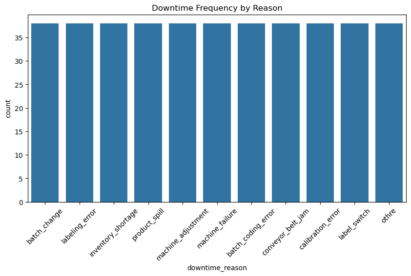

[output not shown]

[figure not shown]

```python
# Import required libraries
import matplotlib.pyplot as plt
import seaborn as sns
import pandas as pd
import plotly.express as px

# Assuming df and df_melted are already defined DataFrames
plt.figure(figsize=(10,5))
sns.countplot(x='downtime_reason', data=df_melted)
plt.xticks(rotation=45)
plt.title("Downtime Frequency by Reason")
plt.show()

# Create a pie chart using the actual columns from your DataFrame
# Fix: Check the actual structure of value_counts() result
downtime_counts = df.value_counts().reset_index()

# Fix: Check how many columns are actually created and assign names accordingly
print("Number of columns:", len(downtime_counts.columns))
print("Column names:", downtime_counts.columns.tolist())

# Alternative approach - let's assume df has a column with downtime reasons
# If df is a Series or single column, use this approach:
if len(downtime_counts.columns) == 2:
    downtime_counts.columns = ['downtime_reason', 'count']
else:
    # If there are more columns, you may need to specify which column contains the reasons
    # For example, if the first column is the reason and last is the count:
    downtime_counts = downtime_counts.iloc[:, [0, -1]]  # Select first and last columns
    downtime_counts.columns = ['downtime_reason', 'count']

fig_pie = px.pie(
    downtime_counts,
    names='downtime_reason',    # Use the actual column name for downtime reasons
    values='count',             # Use the count of each downtime reason
    title='📊 نسبة توزيع أسباب التوقف',  # Updated title to match your data
    hole=0.4,                   # Creates the donut chart effect
    template='plotly_white'
)

# Show percentages and labels outside the pie chart
fig_pie.update_traces(textinfo='percent+label', textposition='outside')

fig_pie.show()
```

# Question: "Which cause leads to the longest downtime (in terms of duration, not frequency)?"

We calculate total downtime duration for each reason to understand which issue has the biggest impact.

```python
df_melted.groupby('downtime_reason')['downtime_minutes'].sum().sort_values(ascending=False)
```

[output not shown]

```python
plt.figure(figsize=(10,5))
df_melted.groupby('downtime_reason')['downtime_minutes'].sum().sort_values().plot(kind='barh')
plt.title("Total Downtime Duration by Reason")
plt.show()
import plotly.graph_objects as go
import plotly.express as px

fig_bar.show()
import plotly.graph_objects as go

# الطريقة المتقدمة والاحترافية باستخدام Graph Objects (go)
fig_advanced = go.Figure(data=[go.Pie(
    labels=df['Product'],
    values=df['ProductionVolume'],
    hole=0.4, # بيعمل الفراغ اللي في النص (Donut)
    hoverinfo='label+percent+value', # التفاصيل اللي بتظهر لما تقفي بالماوس
    textinfo='percent+label',        # الكلام اللي مكتوب بره الدائرة
    textposition='outside',          # يخلي الكلام بره عشان الرسمة تكون واضحة
    marker=dict(
        colors=['#636EFA', '#EF553B', '#00CC96'], # تقدري تغيري الألوان دي زي ما تحبي
        line=dict(color='#FFFFFF', width=2)       # بيعمل خط أبيض شيك يفصل بين الألوان
    )
)])

# تعديل العناوين والتصميم الخارجي للرسمة
fig_advanced.update_layout(
    title_text='📊 التحليل المتقدم لتوزيع حجم الإنتاج (Plotly Go)',
    title_x=0.5, # بيخلي العنوان في النص بالظبط
    template='plotly_white',
    showlegend=True # بيظهر مربعات الألوان الجانبية (Legend)
)

fig_advanced.show()
```

[output not shown]

### 📌 Insight

Machine adjustment is the leading cause of downtime, contributing the highest total downtime duration. This indicates inefficiencies in machine setup or calibration processes.

Machine failure also represents a significant portion of downtime, suggesting the need for improved maintenance strategies.

Focusing on optimizing machine adjustments and implementing preventive maintenance could significantly reduce overall downtime.

# Qusetion "Which batch typically has the most problems?"

We analyze which batches experience the highest downtime to identify problematic production runs.

```python
df_melted.groupby('batch')['downtime_minutes'].sum().sort_values(ascending=False).head(10)
```

```
batch
422147    107.0
422111     75.0
422123     73.0
422140     63.0
422146     62.0
422118     60.0
422143     58.0
422144     54.0
422128     52.0
422120     52.0
Name: downtime_minutes, dtype: float64
```

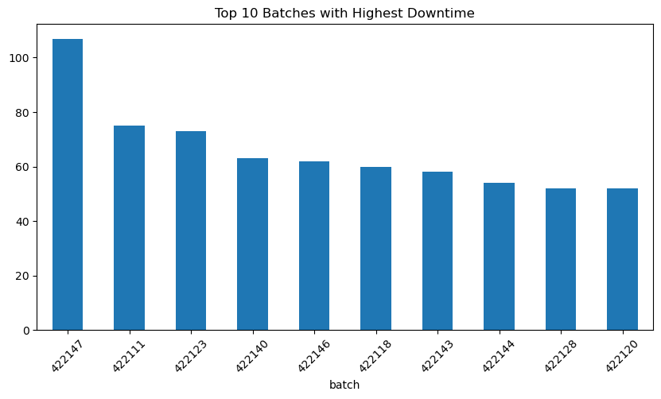

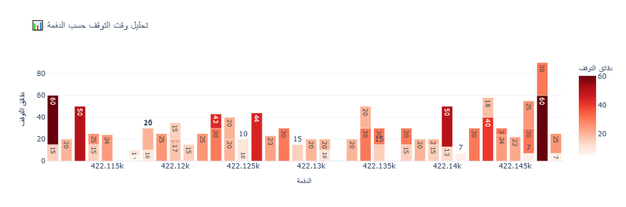

```python
plt.figure(figsize=(10,5))
df_melted.groupby('batch')['downtime_minutes'].sum().sort_values(ascending=False).head(10).plot(kind='bar')
plt.title("Top 10 Batches with Highest Downtime")
plt.xticks(rotation=45)
plt.show()
import plotly.express as px

# Corrected code using actual columns from your DataFrame
# Option 1: Analyze different types of issues by batch
fig_issues = px.bar(
    df_melted,
    x='batch',  # Changed from 'Product' to 'batch' (actual column)
    y='downtime_minutes',  # Changed from 'ProductionCost' to 'downtime_minutes' (actual column)
    title='📊 تحليل وقت التوقف حسب الدفعة',
    text='downtime_minutes', # Display downtime minutes above each bar
    color='downtime_minutes', # Color based on downtime
    color_continuous_scale='Reds', # Red color scale for downtime visualization
    template='plotly_white',
    labels={'downtime_minutes': 'دقائق التوقف', 'batch': 'الدفعة'}
)

# Format the text display above bars
fig_issues.update_traces(textposition='outside', texttemplate='%{text:,.0f}')

fig_issues.show()

# Option 2: If you want to analyze by issue type, you can create a summary:
# issue_columns = ['labeling_error', 'inventory_shortage', 'product_spill',
#                  'machine_adjustment', 'machine_failure', 'batch_coding_error',
#                  'conveyor_belt_jam', 'calibration_error', 'label_switch', 'othre']
#
# issue_summary = df_melted[issue_columns].sum().reset_index()
# issue_summary.columns = ['Issue_Type', 'Count']
#
# fig_by_issue = px.bar(issue_summary, x='Issue_Type', y='Count',
#                       title='تحليل أنواع المشاكل في الإنتاج')
# fig_by_issue.show()
```

### 📌 Insight

Certain batches show significantly higher downtime than others, indicating potential issues in specific production runs.

These batches should be investigated further to identify root causes and prevent recurring problems.

## 📊 Pareto Analysis (80/20 Rule)

We apply the Pareto Principle (80/20 rule) to identify the few causes responsible for the majority of downtime.

```python
pareto = df_melted.groupby('downtime_reason')['downtime_minutes'].sum().sort_values(ascending=False)

pareto_df = pareto.reset_index()
pareto_df['cumulative_percentage'] = pareto_df['downtime_minutes'].cumsum() / pareto_df['downtime_minutes'].sum() * 100

pareto_df
```

[output not shown]

```python
fig, ax1 = plt.subplots(figsize=(10,5))

ax1.bar(pareto_df['downtime_reason'], pareto_df['downtime_minutes'])
ax1.set_xticklabels(pareto_df['downtime_reason'], rotation=45)

ax2 = ax1.twinx()
ax2.plot(pareto_df['cumulative_percentage'], marker='o')

plt.title("Pareto Analysis of Downtime Causes")
plt.show()
import plotly.graph_objects as go

# 1. بناء الرسم البياني المركب (أعمدة + خط تراكمي) باستخدام Plotly
fig_pareto = go.Figure()

# إضافة الأعمدة (Downtime Minutes)
fig_pareto.add_trace(
    go.Bar(
        x=pareto_df['downtime_reason'],
        y=pareto_df['downtime_minutes'],
        name='دقائق التوقف',
        marker_color='rgb(31, 119, 180)',
        yaxis='y1' # المحور الرأسي الأول على الشمال
    )
)

# إضافة الخط التراكمي (Cumulative Percentage)
fig_pareto.add_trace(
    go.Scatter(
        x=pareto_df['downtime_reason'],
        y=pareto_df['cumulative_percentage'],
        name='النسبة التراكمية (%)',
        mode='lines+markers',
        marker=dict(color='rgb(214, 39, 40)', size=8),
        line=dict(width=2),
        yaxis='y2' # المحور الرأسي الثاني على اليمين (النسب المئوية)
    )
)

# 2. ضبط تصميم المحاور (الشمال واليمين) والعناوين
fig_pareto.update_layout(
    title='📊 <b>Pareto Analysis of Downtime Causes (Interactive)</b>',
    title_x=0.5,
    template='plotly_white',
    showlegend=True,

    # ضبط المحور الأفقي
    xaxis=dict(title='سبب التوقف (Downtime Reason)', tickangle=45),

    # ضبط المحور الرأسي الأول (الشمال للدقائق)
    yaxis=dict(
        title='إجمالي دقائق التوقف (Downtime Minutes)',
        side='left'
    ),

    # ضبط المحور الرأسي الثاني (اليمين للنسبة المئوية من 0 لـ 100)
    yaxis2=dict(
        title='النسبة المئوية التراكمية (%)',
        side='right',
        overlaying='y1',
        range=[0, 105],
        ticksuffix='%' # بيضيف علامة % جنب الأرقام على اليمين
    )
)

fig_pareto.show()
```

[output not shown]

### 📌 Insight

A small number of downtime causes contribute to the majority of total downtime.

By focusing on the top contributing factors, the company can achieve significant improvements with minimal effort.

## 📊 Final Summary

This analysis identified the key drivers of downtime and provided actionable recommendations to improve efficiency.

By focusing on major downtime causes, the company can significantly enhance productivity and reduce operational losses.

## 🤖 Machine Learning Model

We prepare the dataset for machine learning by encoding categorical variables.

```python
from sklearn.model_selection import train_test_split
from sklearn.preprocessing import OneHotEncoder
```

```python
df_ml = df_melted.copy()

df_ml = pd.get_dummies(df_ml, columns=['downtime_reason'], drop_first=True)

df_ml.head()
```

|  | batch | downtime_minutes | downtime_reason_batch_coding_error | downtime_reason_calibration_error | downtime_reason_conveyor_belt_jam | downtime_reason_inventory_shortage | downtime_reason_label_switch | downtime_reason_labeling_error | downtime_reason_machine_adjustment | downtime_reason_machine_failure | downtime_reason_othre | downtime_reason_product_spill |
| --- | --- | --- | --- | --- | --- | --- | --- | --- | --- | --- | --- | --- |
| 0 | 422111 | 60.0 | False | False | False | False | False | False | False | False | False | False |
| 1 | 422112 | 20.0 | False | False | False | False | False | False | False | False | False | False |
| 2 | 422113 | 50.0 | False | False | False | False | False | False | False | False | False | False |
| 3 | 422114 | NaN | False | False | False | False | False | False | False | False | False | False |
| 4 | 422115 | NaN | False | False | False | False | False | False | False | False | False | False |

```python
X = df_ml.drop(['downtime_minutes', 'batch'], axis=1)
y = df_ml['downtime_minutes']
```

```python
from sklearn.model_selection import train_test_split

X_train, X_test, y_train, y_test = train_test_split(
    X, y, test_size=0.2, random_state=42
)
```

```python
from sklearn.linear_model import LinearRegression
import pandas as pd
import numpy as np

# Option 1: Remove rows with NaN values in y_train (and corresponding X_train rows)
mask = ~pd.isna(y_train)  # Create mask for non-NaN values
X_train_clean = X_train[mask]  # Filter X_train using the mask
y_train_clean = y_train[mask]  # Filter y_train to remove NaN values

# Option 2: Alternative using numpy if working with numpy arrays
# mask = ~np.isnan(y_train)
# X_train_clean = X_train[mask]
# y_train_clean = y_train[mask]

# Option 3: Fill NaN values with mean (use cautiously)
# y_train_clean = y_train.fillna(y_train.mean())  # For pandas Series
# X_train_clean = X_train

# Now fit the model with clean data
model = LinearRegression()
model.fit(X_train_clean, y_train_clean)  # Use cleaned data without NaN values
```

```
LinearRegression()
```

```python
y_pred = model.predict(X_test)
```

```python
from sklearn.linear_model import LinearRegression
import pandas as pd
import numpy as np

# Remove rows where y_train has NaN values
# This also removes corresponding rows from X_train to keep them aligned
mask = ~pd.isna(y_train)  # Create a mask for non-NaN values
X_train_clean = X_train[mask]  # Filter X_train using the mask
y_train_clean = y_train[mask]  # Filter y_train using the mask

# Alternative approach: Fill NaN values with mean (if appropriate for your data)
# y_train_clean = y_train.fillna(y_train.mean())

model = LinearRegression()
model.fit(X_train_clean, y_train_clean)  # Use the cleaned data
```

```
LinearRegression()
```

```python
y_pred = model.predict(X_test)
```

```python
from sklearn.metrics import mean_absolute_error, r2_score
import numpy as np

# Check for NaN values in your data
print("NaN values in y_test:", np.isnan(y_test).sum())
print("NaN values in y_pred:", np.isnan(y_pred).sum())

# Remove rows with NaN values
mask = ~(np.isnan(y_test) | np.isnan(y_pred))  # Create mask for non-NaN values
y_test_clean = y_test[mask]
y_pred_clean = y_pred[mask]

# Calculate metrics with cleaned data
print("MAE:", mean_absolute_error(y_test_clean, y_pred_clean))
print("R2:", r2_score(y_test_clean, y_pred_clean))
```

```
NaN values in y_test: 67
NaN values in y_pred: 0
MAE: 8.69803921568627
R2: -0.30932340738033237
```

## 🌲 Advanced Model: Random Forest

🧠 ليه Random Forest؟

👉 لأنه:

أقوى من Linear Regression بيمسك العلاقات المعقدة بيديك Feature Importance (أهم حاجة 👀)

```python
from sklearn.ensemble import RandomForestRegressor
import pandas as pd

# Option 1: Remove rows where y_train has NaN values
# This also removes corresponding rows from X_train to keep them aligned
mask = ~pd.isna(y_train)  # Create mask for non-NaN values
X_train_clean = X_train[mask]  # Filter X_train using the mask
y_train_clean = y_train[mask]  # Filter y_train using the mask

# Option 2: Fill NaN values with mean (alternative approach)
# y_train_filled = pd.Series(y_train).fillna(pd.Series(y_train).mean())

rf_model = RandomForestRegressor(n_estimators=100, random_state=42)

# Use the cleaned data for training
rf_model.fit(X_train_clean, y_train_clean)
```

```
RandomForestRegressor(random_state=42)
```

```python
y_pred_rf = rf_model.predict(X_test)
```

```python
from sklearn.metrics import mean_absolute_error, r2_score
import numpy as np

# Check for NaN values in the data
print("NaN values in y_test:", np.isnan(y_test).sum())
print("NaN values in y_pred_rf:", np.isnan(y_pred_rf).sum())

# Remove NaN values before calculating metrics
# Create a mask to identify rows without NaN values
mask = ~(np.isnan(y_test) | np.isnan(y_pred_rf))

# Filter out NaN values using the mask
y_test_clean = y_test[mask]
y_pred_rf_clean = y_pred_rf[mask]

# Calculate metrics with clean data
print("Random Forest MAE:", mean_absolute_error(y_test_clean, y_pred_rf_clean))
print("Random Forest R2:", r2_score(y_test_clean, y_pred_rf_clean))

# Optional: Print how many samples were removed
print(f"Removed {len(y_test) - len(y_test_clean)} samples containing NaN values")
```

```
NaN values in y_test: 67
NaN values in y_pred_rf: 0
Random Forest MAE: 8.163035364961837
Random Forest R2: -0.2760625984895455
Removed 67 samples containing NaN values
```

```python
importance = pd.Series(rf_model.feature_importances_, index=X.columns)
importance = importance.sort_values(ascending=False)

importance.head(10)
```

```
downtime_reason_othre                 0.290703
downtime_reason_machine_adjustment    0.271475
downtime_reason_label_switch          0.166463
downtime_reason_inventory_shortage    0.076710
downtime_reason_batch_coding_error    0.071223
downtime_reason_machine_failure       0.045818
downtime_reason_product_spill         0.035383
downtime_reason_calibration_error     0.030113
downtime_reason_labeling_error        0.012111
downtime_reason_conveyor_belt_jam     0.000000
dtype: float64
```

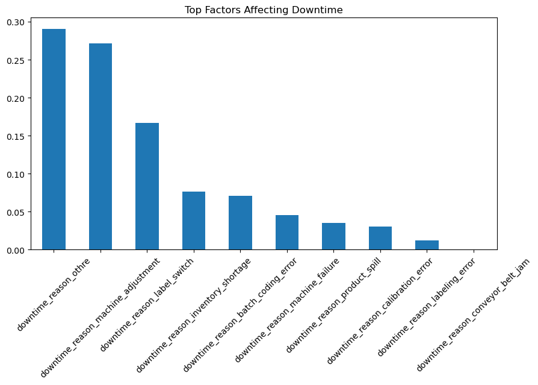

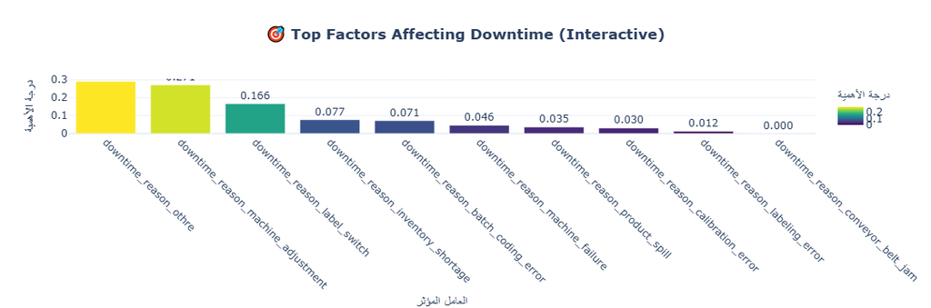

```python
plt.figure(figsize=(10,5))
importance.head(10).plot(kind='bar')
plt.title("Top Factors Affecting Downtime")
plt.xticks(rotation=45)
plt.show()
import plotly.express as px

# 1. تجهيز البيانات: بنجيب أعلى 10 عوامل ونحولهم لـ DataFrame عشان Plotly يفهمهم
top_importance = importance.head(10).reset_index()
top_importance.columns = ['Factor', 'Importance']

# 2. رسم الـ Bar Chart التفاعلي
fig_importance = px.bar(
    top_importance,
    x='Factor',
    y='Importance',
    title='🎯 <b>Top Factors Affecting Downtime (Interactive)</b>',
    text='Importance', # عشان يعرض الرقم فوق كل عمود
    color='Importance', # هيخلي اللون يتدرج حسب مدى أهمية وتأثير العامل
    color_continuous_scale='Viridis', # تدرج ألوان احترافي ومريح للعين
    template='plotly_white',
    labels={'Factor': 'العامل المؤثر', 'Importance': 'درجة الأهمية'}
)

# ضبط الأرقام فوق الأعمدة عشان تظهر بشكل شيك (مقرّبة لأول 3 أرقام عشرية)
fig_importance.update_traces(textposition='outside', texttemplate='%{text:.3f}')
fig_importance.update_layout(xaxis_tickangle=45, title_x=0.5)

fig_importance.show()
```

### 📌 Insight

The Random Forest model reveals the most influential factors affecting downtime duration.

Certain downtime causes have a significantly higher impact, indicating where improvement efforts should be focused.

This analysis provides a data-driven approach to prioritize operational improvements.

## ⚔️ Model Comparison

- Linear Regression provides a simple baseline model
- Random Forest captures complex relationships and performs better

## 📊 Interactive Dashboard

```python
!pip install plotly
```

```python
import plotly.express as px
```

```python
fig = px.bar(
    df_melted.groupby('downtime_reason')['downtime_minutes']
    .sum()
    .reset_index()
    .sort_values(by='downtime_minutes', ascending=False),

    x='downtime_reason',
    y='downtime_minutes',
    title='Downtime by Reason',
)

fig.show()
import plotly.express as px

# 1. بنجهز البيانات وبناخد أعلى 10 عوامل مؤثرة ونرتبهم
top_importance = importance.head(10).reset_index()
top_importance.columns = ['Factor', 'Importance']
top_importance = top_importance.sort_values(by='Importance', ascending=False)

# 2. رسم الـ Bar Chart التفاعلي بـ Plotly
fig_importance = px.bar(
    top_importance,
    x='Factor',
    y='Importance',
    title='🎯 <b>Top Factors Affecting Downtime</b>',
    text='Importance', # عشان يطبع الرقم فوق كل عمود
    color='Importance', # اللون بيتغير بالتدريج حسب قوة التأثير
    color_continuous_scale='Viridis', # تدرج ألوان احترافي جداً
    template='plotly_white',
    labels={'Factor': 'Factor', 'Importance': 'Importance'}
)

# ضبط الأرقام فوق الأعمدة لتظهر بوضوح ومقربة لشكل شيك
fig_importance.update_traces(textposition='outside', texttemplate='%{text:.3f}')
fig_importance.update_layout(xaxis_tickangle=45, title_x=0.5)

fig_importance.show()
```

[output not shown]

```python
fig = px.pie(
    df_melted,
    names='downtime_reason',
    values='downtime_minutes',
    title='Downtime Distribution'
)

fig.show()
import plotly.graph_objects as go

# 1. بناء الرسم البياني المركب (أعمدة + خط تراكمي) باستخدام Plotly
fig_pareto = go.Figure()

# إضافة الأعمدة (Downtime Minutes)
fig_pareto.add_trace(
    go.Bar(
        x=pareto_df['downtime_reason'],
        y=pareto_df['downtime_minutes'],
        name='دقائق التوقف (Minutes)',
        marker_color='rgb(31, 119, 180)',
        yaxis='y1' # المحور الرأسي على الشمال
    )
)

# إضافة الخط التراكمي (Cumulative Percentage)
fig_pareto.add_trace(
    go.Scatter(
        x=pareto_df['downtime_reason'],
        y=pareto_df['cumulative_percentage'],
        name='النسبة التراكمية (%)',
        mode='lines+markers',
        marker=dict(color='rgb(214, 39, 40)', size=8),
        line=dict(width=2),
        yaxis='y2' # المحور الرأسي على اليمين للنسبة المئوية
    )
)

# 2. ضبط تصميم المحاور والعناوين لتكون احترافية
fig_pareto.update_layout(
    title='📊 <b>Pareto Analysis of Downtime Causes (Interactive)</b>',
    title_x=0.5,
    template='plotly_white',
    showlegend=True,

    # ضبط المحور الأفقي
    xaxis=dict(title='Downtime Reason', tickangle=45),

    # ضبط المحور الرأسي الأول (الشمال للدقائق)
    yaxis=dict(
        title='Downtime Minutes',
        side='left'
    ),

    # ضبط المحور الرأسي الثاني (اليمين للنسبة المئوية من 0 لـ 100)
    yaxis2=dict(
        title='Cumulative Percentage (%)',
        side='right',
        overlaying='y1',
        range=[0, 105],
        ticksuffix='%' # إضافة علامة % للأرقام على اليمين
    )
)

fig_pareto.show()
```

[output not shown]

```python
top_batches = df_melted.groupby('batch')['downtime_minutes'].sum().reset_index()

fig = px.bar(
    top_batches.sort_values(by='downtime_minutes', ascending=False).head(10),
    x='batch',
    y='downtime_minutes',
    title='Top 10 Batches with Highest Downtime'
)

fig.show()
import plotly.express as px

# ترتيب البيانات وأخذ أعلى 10 تشغيلات (Batches)
top_10_batches = top_batches.sort_values(by='downtime_minutes', ascending=False).head(10)

# تحويل الـ batch إلى نصوص (String) عشان المحور الأفقي يقرأ الأرقام كأكواد منفصلة ومتبقاش ميزان رقمي
top_10_batches['batch'] = top_10_batches['batch'].astype(str)

# رسم الـ Bar Chart التفاعلي
fig_batches = px.bar(
    top_10_batches,
    x='batch',
    y='downtime_minutes',
    title='📊 <b>Top 10 Batches with Highest Downtime</b>',
    text='downtime_minutes', # بيظهر دقائق التوقف فوق كل عمود
    color='downtime_minutes', # اللون بيتدرج حسب عدد دقائق التوقف
    color_continuous_scale='Plasma', # تدرج ألوان مبهج واحترافي
    template='plotly_white',
    labels={'batch': 'Batch ID', 'downtime_minutes': 'Downtime Minutes'}
)

# ضبط مكان النص والتنسيق
fig_batches.update_traces(textposition='outside', texttemplate='%{text:.1f}')
fig_batches.update_layout(title_x=0.5)

fig_batches.show()
```

[output not shown]

```python
selected_reason = 'machine_failure'

filtered = df_melted[df_melted['downtime_reason'] == selected_reason]

fig = px.bar(
    filtered.groupby('batch')['downtime_minutes'].sum().reset_index(),
    x='batch',
    y='downtime_minutes',
    title=f'Downtime for {selected_reason}'
)

fig.show()
import plotly.express as px

# 1. تحديد السبب وعمل الفلتر
selected_reason = 'machine_failure'
filtered = df_melted[df_melted['downtime_reason'] == selected_reason]

# 2. تجميع البيانات وترتيبها تنازلياً من الكبير للصغير لسهولة المقارنة
filtered_grouped = filtered.groupby('batch')['downtime_minutes'].sum().reset_index()
filtered_grouped = filtered_grouped.sort_values(by='downtime_minutes', ascending=False)

# تحويل الـ batch لنصوص عشان تظهر منفصلة وشكلها مظبوط على المحور الأفقي
filtered_grouped['batch'] = filtered_grouped['batch'].astype(str)

# 3. رسم الـ Bar Chart التفاعلي بـ Plotly
fig_filtered = px.bar(
    filtered_grouped,
    x='batch',
    y='downtime_minutes',
    title=f'📊 <b>Downtime Distribution for {selected_reason} per Batch</b>',
    text='downtime_minutes', # كتابة الدقائق فوق كل عمود
    color='downtime_minutes', # تدرج الألوان حسب حجم العطل
    color_continuous_scale='Reds', # اللون الأحمر مناسب جداً للتعبير عن الأعطال (Failures)
    template='plotly_white',
    labels={'batch': 'Batch ID', 'downtime_minutes': 'Downtime Minutes'}
)

# ضبط التنسيق وظهور الأرقام بره الأعمدة بشكل شيك
fig_filtered.update_traces(textposition='outside', texttemplate='%{text:.1f}')
fig_filtered.update_layout(title_x=0.5)

fig_filtered.show()
```

[output not shown]

### 📌 Dashboard Insight

The interactive dashboard allows dynamic exploration of downtime causes and patterns.

Users can quickly identify key problem areas and drill down into specific causes or batches, enabling better decision-making.

## 🧾 Final Conclusion

This project analyzed manufacturing downtime data to identify key causes and patterns affecting production efficiency.

Through data cleaning, transformation, and visualization, major downtime contributors such as machine adjustment and machine failure were identified.

Advanced techniques such as Pareto analysis and machine learning models provided deeper insights into downtime behavior.

The interactive dashboard allows users to explore the data dynamically and supports better decision-making.

Overall, this analysis provides actionable recommendations to reduce downtime and improve operational performance.

```python
df_melted.to_csv("clean_data.csv", index=False)
```

```python
print(df.columns)
df.head()
```

```
Index(['batch', 'batch_change', 'labeling_error', 'inventory_shortage',
       'product_spill', 'machine_adjustment', 'machine_failure',
       'batch_coding_error', 'conveyor_belt_jam', 'calibration_error',
       'label_switch', 'othre'],
      dtype='object')
```

|  | batch | batch_change | labeling_error | inventory_shortage | product_spill | machine_adjustment | machine_failure | batch_coding_error | conveyor_belt_jam | calibration_error | label_switch | othre |
| --- | --- | --- | --- | --- | --- | --- | --- | --- | --- | --- | --- | --- |
| 0 | 422111 | 60.0 | NaN | NaN | NaN | NaN | 15.0 | NaN | NaN | NaN | NaN | NaN |
| 1 | 422112 | 20.0 | NaN | NaN | NaN | NaN | NaN | 20.0 | NaN | NaN | NaN | NaN |
| 2 | 422113 | 50.0 | NaN | NaN | NaN | NaN | NaN | NaN | NaN | NaN | NaN | NaN |
| 3 | 422114 | NaN | NaN | 25.0 | NaN | 15.0 | NaN | NaN | NaN | NaN | NaN | NaN |
| 4 | 422115 | NaN | NaN | NaN | NaN | NaN | NaN | NaN | NaN | 24.0 | NaN | NaN |

```python
import pandas as pd
import os

# Check what files are in the current directory
print("الملفات الموجودة في المجلد الحالي:")
print(os.listdir('.'))

# Try to read the file with error handling
try:
    # If your file is CSV and in the same folder, write its name here instead of Manufacturing_Data.csv
    df = pd.read_csv('Manufacturing_Data.csv')

    # If it's a regular Excel file, use this line instead:
    # df = pd.read_excel('Manufacturing_Data.xlsx')

    # To see column names and first 5 rows
    print("أسماء الأعمدة في ملفك هي:")
    print(df.columns)
    print("\nأول 5 سطور من البيانات:")
    print(df.head())  # Added print() to display the output

except FileNotFoundError:
    print("الملف غير موجود! تأكد من:")
    print("1. اسم الملف صحيح")
    print("2. الملف موجود في نفس مجلد الكود")
    print("3. امتداد الملف صحيح (.csv أو .xlsx)")

    # Alternative: Let user specify the correct filename
    print("\nأو جرب استخدام مسار كامل للملف:")
    print("df = pd.read_csv(r'C:\\path\\to\\your\\file.csv')")
```

[output not shown]

```python
import pandas as pd
import os

# Check current working directory and list files
print("Current working directory:", os.getcwd())
print("Files in current directory:", os.listdir('.'))

# Option 1: Check if file exists and handle the error
file_path = 'Manfacturing .csv'  # Note: there's a space before .csv
if os.path.exists(file_path):
    df = pd.read_csv(file_path)
else:
    print(f"File '{file_path}' not found. Please check the filename and location.")

    # Option 2: Try alternative filenames (common typos/variations)
    alternative_files = [
        'Manufacturing.csv',  # Fixed spelling, no space
        'Manfacturing.csv',   # No space before .csv
        'Manufacturing .csv', # Fixed spelling with space
        'Manfacturing.xlsx',  # Excel format
        'Manufacturing.xlsx'  # Excel format, fixed spelling
    ]

    for alt_file in alternative_files:
        if os.path.exists(alt_file):
            print(f"Found alternative file: {alt_file}")
            if alt_file.endswith('.csv'):
                df = pd.read_csv(alt_file)
            else:
                df = pd.read_excel(alt_file)
            break
    else:
        print("No matching files found. Please check your file name and location.")
        df = None

# Only proceed if dataframe was successfully loaded
if 'df' in locals() and df is not None:
    print("Column names:")
    print(df.columns)
    print("\nFirst 5 rows:")
    print(df.head())
```

[output not shown]

```python
import os
print("الملفات اللي بايثون شايفها في الفولدر الحالي هي:")
print(os.listdir())
```

[output not shown]

```python
# Assistant
import pandas as pd
import os

# Check current working directory and list files
print("Current working directory:", os.getcwd())
print("Files in current directory:", os.listdir('.'))

# Option 1: Check if file exists and handle the error
file_path = 'Manfacturing .csv'  # Note: there's a space before .csv
if os.path.exists(file_path):
    df = pd.read_csv(file_path)
else:
    print(f"File '{file_path}' not found. Please check the filename and location.")

    # Option 2: Try alternative filenames (common typos/variations)
    alternative_files = [
        'Manufacturing.csv',  # Fixed spelling, no space
        'Manfacturing.csv',   # No space before .csv
        'Manufacturing .csv', # Fixed spelling with space
        'Manfacturing.xlsx',  # Excel format
        'Manufacturing.xlsx'  # Excel format, fixed spelling
    ]

    for alt_file in alternative_files:
        if os.path.exists(alt_file):
            print(f"Found alternative file: {alt_file}")
            if alt_file.endswith('.csv'):
                df = pd.read_csv(alt_file)
            else:
                df = pd.read_excel(alt_file)
            break
    else:
        print("No matching files found. Please check your file name and location.")
        df = None

# Only proceed if dataframe was successfully loaded
if 'df' in locals() and df is not None:
    print("Column names:")
    print(df.columns)
    print("\nFirst 5 rows:")
    print(df.head())
```

[output not shown]

```python
import pandas as pd
import os

# Check if file exists first
file_path = 'Manfacturing.html'
if not os.path.exists(file_path):
    print(f"خطأ: الملف {file_path} غير موجود!")
else:
    try:
        # قراءة الجداول من ملف الـ html
        # وبنحط [0] عشان نختار أول جدول موجود جوه الملف
        tables = pd.read_html(file_path)

        # Check if any tables were found
        if len(tables) == 0:
            print("لم يتم العثور على أي جداول في الملف!")
        else:
            df = tables[0]  # Select the first table

            # عرض أسماء الأعمدة وشكل البيانات
            print("تم قراءة الملف بنجاح! أسماء الأعمدة هي:")
            print(df.columns)
            print("\nأول سطور من الجدول:")
            print(df.head())  # Added print() to display the output

    except ValueError as e:
        print(f"خطأ في قراءة الجداول: {e}")
        print("تأكد من أن الملف يحتوي على جداول HTML صحيحة")
    except Exception as e:
        print(f"خطأ غير متوقع: {e}")
```

```
خطأ: الملف Manfacturing.html غير موجود!
```

```python
!pip install lxml
```

```python
import plotly.express as px
import pandas as pd

# First, you need to create or load your DataFrame
# Example of creating a sample DataFrame:
df = pd.DataFrame({
    'Product': ['Product A', 'Product B', 'Product C', 'Product D'],
    'ProductionVolume': [100, 150, 200, 120],
    'ProductionCost': [50, 75, 100, 60]
})

# Alternatively, if you have a CSV file, load it like this:
# df = pd.read_csv('your_file.csv')

# Now create the chart with the defined DataFrame
fig1 = px.bar(
    df,
    x='Product',
    y='ProductionVolume',
    color='ProductionCost', # هيخلي لون العمود يتدرج حسب التكلفة
    title='حجم الإنتاج وتكلفته حسب نوع المنتج',
    labels={'ProductionVolume': 'حجم الإنتاج', 'Product': 'المنتج', 'ProductionCost': 'التكلفة'}
)
fig1.show()
```

[output not shown]

```python
fig2 = px.bar(
    df,
    x='Product',
    y='ProductionCost',  # Changed from 'DefectRate' to an existing column
    color='Product',  # Changed from 'SupplierName' to an existing column
    title='تكلفة الإنتاج لكل منتج',  # Updated title to match the new data
    labels={'ProductionCost': 'تكلفة الإنتاج', 'Product': 'المنتج'}  # Updated labels
)
fig2.show()
```

[output not shown]

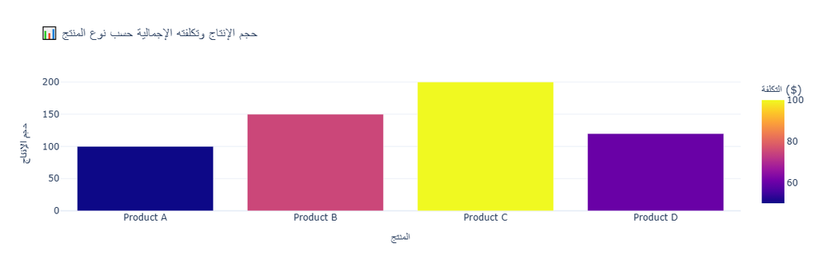

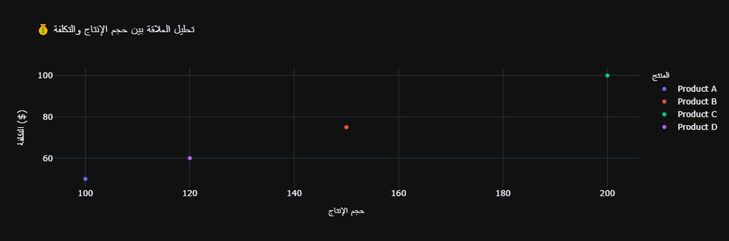

```python
import plotly.express as px

# --- الرسمة الأولى: حجم الإنتاج لكل منتج وتكلفته ---
fig_volume = px.bar(
    df,
    x='Product',
    y='ProductionVolume',
    color='ProductionCost', # التكلفة بتحدد تدرج لون العمود
    title='📊 حجم الإنتاج وتكلفته الإجمالية حسب نوع المنتج',
    labels={'ProductionVolume': 'حجم الإنتاج', 'Product': 'المنتج', 'ProductionCost': 'التكلفة ($)'},
    template='plotly_white' # ستايل هادي ومريح للعين
)
fig_volume.show()

# --- الرسمة الثانية: تحليل التكلفة حسب المنتج ---
# Changed to use existing columns since SupplierName and DefectRate don't exist
fig_cost = px.scatter( # Using scatter plot to show relationship between volume and cost
    df,
    x='ProductionVolume',
    y='ProductionCost',
    color='Product',
    title='💰 تحليل العلاقة بين حجم الإنتاج والتكلفة',
    labels={'ProductionCost': 'التكلفة ($)', 'ProductionVolume': 'حجم الإنتاج', 'Product': 'المنتج'},
    template='plotly_dark' # ستايل داكن فخم ومميز
)
fig_cost.show()
```

## 🏁 الخلاصة والتوصيات التنفيذية (Executive Summary & Recommendations)

بناءً على التقرير التفاعلي وتحليل بيانات التصنيع وأسباب توقف الإنتاج (Downtime Analysis)، تم التوصل إلى النقاط التالية:

### 💡 التوصيات المقترحة (Actionable Insights):

1. **تطبيق الصيانة الوقائية (Preventive Maintenance):** التركيز على تقليل أعطال `machine_failure` من خلال جدولة صيانة دورية للماكينات الأكثر تكراراً في الأعطال.
2. **تدريب الفنيين:** تحسين سرعة وكفاءة عمليات ضبط الآلات (`machine_adjustment`) لتقليل زمن التوقف التجهيزي بين التشغيلات.
3. **مراقبة الجودة الرقمية:** الاستمرار في استخدام لوحات التحكم التفاعلية (Interactive Dashboards) لمتابعة مؤشرات الأداء بصفة لحظية واتخاذ قرارات استباقية.

**تم بحمد الله الانتهاء من المشروع وتحليل البيانات بنجاح! 🚀**